# Table of Content

1. Introduction
2. Recaping Business and Analytics Problem
3. EDA Continued
4. Data Cleaning
5. Mising Data
6. Modeling Process
7. Results
8. Appendix

## 1. Introduction

Home Credit is a multinational financial institution that specializes in providing loans to individuals with inadequate credit history. They aim to promote financial inclusion by offering accessible financial services to underprivileged populations. Home Credit develops creative financing solutions by using non-traditional data sources and other alternative techniques to evaluate creditworthiness. Their customer-centric approach and fast, convenient lending process empower individuals to make important purchases and build a positive credit history. Home Credit reduces the risks involved with lending to borrowers with spotty credit histories by using advanced risk management models. Overall, they strive to democratize access to financial services and create a positive social impact.

This notebook will walk you through the data available and how that data is used to train a model which Home Credit will then use to predict if a future applicant will default on their loan or not.

## 2. Recaping Business and Analytic Problems

Home Credit's business model is to address the financial challenges faced by individuals with insufficient or non-existent credit histories. We recognized that this underserved population often falls victim to untrustworthy lenders. Home Credit is committed to providing a positive and safe borrowing experience, with the aim of broadening financial inclusion. To achieve this goal, they currently leverage alternative data sources, such as property ownership and transactional information, to assess the repayment abilities of their clients. However, they believe that there is untapped potential in the market.

To unlock Home Credit's full potential, we aim to optimize data analysis techniques and algorithms by leveraging available data to identify clients capable of repayment. This will prevent unnecessary rejections, increase the rate of correct rejection, and provide loans to suitable parties. This project will support current prediction methods and provide a precise prediction model, based on additional analytics by employing various statistical and machine learning techniques to make accurate predictions.

## 3. EDA Continued

### Data import and loading

```python
import pandas as pd
import numpy as np
import matplotlib
import matplotlib.pyplot as plt
import seaborn as sns
import missingno as msno
import os
import warnings
warnings.filterwarnings('ignore')
from sklearn import preprocessing
from sklearn.preprocessing import LabelEncoder
import xgboost as xgb
import lightgbm as lgb
from xgboost import XGBClassifier
from xgboost import plot_importance
from sklearn.model_selection import GridSearchCV
from sklearn.metrics import accuracy_score, precision_score, recall_score, f1_score, roc_auc_score, confusion_matrix
```

```python
from google.colab import drive
drive.mount('/content/drive')
folder_path = '/content/drive/MyDrive/home-credit-default-risk/'
```

```python
application_train = pd.read_csv(folder_path+'application_train.csv')
POS_CASH_balance = pd.read_csv(folder_path+'POS_CASH_balance.csv')
bureau_balance = pd.read_csv(folder_path+'bureau_balance.csv')
previous_application = pd.read_csv(folder_path+'previous_application.csv')
installments_payments = pd.read_csv(folder_path+'installments_payments.csv')
credit_card_balance = pd.read_csv(folder_path+'credit_card_balance.csv')
bureau = pd.read_csv(folder_path+'bureau.csv')
application_test = pd.read_csv(folder_path+'application_test.csv')
```

```python
application_train.head()
```

|  | SK_ID_CURR | TARGET | NAME_CONTRACT_TYPE | CODE_GENDER | FLAG_OWN_CAR | FLAG_OWN_REALTY | CNT_CHILDREN | AMT_INCOME_TOTAL | AMT_CREDIT | AMT_ANNUITY | ... | FLAG_DOCUMENT_18 | FLAG_DOCUMENT_19 | FLAG_DOCUMENT_20 | FLAG_DOCUMENT_21 | AMT_REQ_CREDIT_BUREAU_HOUR | AMT_REQ_CREDIT_BUREAU_DAY | AMT_REQ_CREDIT_BUREAU_WEEK | AMT_REQ_CREDIT_BUREAU_MON | AMT_REQ_CREDIT_BUREAU_QRT | AMT_REQ_CREDIT_BUREAU_YEAR |
| --- | --- | --- | --- | --- | --- | --- | --- | --- | --- | --- | --- | --- | --- | --- | --- | --- | --- | --- | --- | --- | --- |
| 0 | 100002 | 1 | Cash loans | M | N | Y | 0 | 202500.0 | 406597.5 | 24700.5 | ... | 0 | 0 | 0 | 0 | 0.0 | 0.0 | 0.0 | 0.0 | 0.0 | 1.0 |
| 1 | 100003 | 0 | Cash loans | F | N | N | 0 | 270000.0 | 1293502.5 | 35698.5 | ... | 0 | 0 | 0 | 0 | 0.0 | 0.0 | 0.0 | 0.0 | 0.0 | 0.0 |
| 2 | 100004 | 0 | Revolving loans | M | Y | Y | 0 | 67500.0 | 135000.0 | 6750.0 | ... | 0 | 0 | 0 | 0 | 0.0 | 0.0 | 0.0 | 0.0 | 0.0 | 0.0 |
| 3 | 100006 | 0 | Cash loans | F | N | Y | 0 | 135000.0 | 312682.5 | 29686.5 | ... | 0 | 0 | 0 | 0 | NaN | NaN | NaN | NaN | NaN | NaN |
| 4 | 100007 | 0 | Cash loans | M | N | Y | 0 | 121500.0 | 513000.0 | 21865.5 | ... | 0 | 0 | 0 | 0 | 0.0 | 0.0 | 0.0 | 0.0 | 0.0 | 0.0 |

5 rows × 122 columns

```python
POS_CASH_balance.head()
```

|  | SK_ID_PREV | SK_ID_CURR | MONTHS_BALANCE | CNT_INSTALMENT | CNT_INSTALMENT_FUTURE | NAME_CONTRACT_STATUS | SK_DPD | SK_DPD_DEF |
| --- | --- | --- | --- | --- | --- | --- | --- | --- |
| 0 | 1803195 | 182943 | -31 | 48.0 | 45.0 | Active | 0 | 0 |
| 1 | 1715348 | 367990 | -33 | 36.0 | 35.0 | Active | 0 | 0 |
| 2 | 1784872 | 397406 | -32 | 12.0 | 9.0 | Active | 0 | 0 |
| 3 | 1903291 | 269225 | -35 | 48.0 | 42.0 | Active | 0 | 0 |
| 4 | 2341044 | 334279 | -35 | 36.0 | 35.0 | Active | 0 | 0 |

```python
bureau_balance.head()
```

|  | SK_ID_BUREAU | MONTHS_BALANCE | STATUS |
| --- | --- | --- | --- |
| 0 | 5715448 | 0 | C |
| 1 | 5715448 | -1 | C |
| 2 | 5715448 | -2 | C |
| 3 | 5715448 | -3 | C |
| 4 | 5715448 | -4 | C |

```python
previous_application.head()
```

|  | SK_ID_PREV | SK_ID_CURR | NAME_CONTRACT_TYPE | AMT_ANNUITY | AMT_APPLICATION | AMT_CREDIT | AMT_DOWN_PAYMENT | AMT_GOODS_PRICE | WEEKDAY_APPR_PROCESS_START | HOUR_APPR_PROCESS_START | ... | NAME_SELLER_INDUSTRY | CNT_PAYMENT | NAME_YIELD_GROUP | PRODUCT_COMBINATION | DAYS_FIRST_DRAWING | DAYS_FIRST_DUE | DAYS_LAST_DUE_1ST_VERSION | DAYS_LAST_DUE | DAYS_TERMINATION | NFLAG_INSURED_ON_APPROVAL |
| --- | --- | --- | --- | --- | --- | --- | --- | --- | --- | --- | --- | --- | --- | --- | --- | --- | --- | --- | --- | --- | --- |
| 0 | 2030495 | 271877 | Consumer loans | 1730.430 | 17145.0 | 17145.0 | 0.0 | 17145.0 | SATURDAY | 15 | ... | Connectivity | 12.0 | middle | POS mobile with interest | 365243.0 | -42.0 | 300.0 | -42.0 | -37.0 | 0.0 |
| 1 | 2802425 | 108129 | Cash loans | 25188.615 | 607500.0 | 679671.0 | NaN | 607500.0 | THURSDAY | 11 | ... | XNA | 36.0 | low_action | Cash X-Sell: low | 365243.0 | -134.0 | 916.0 | 365243.0 | 365243.0 | 1.0 |
| 2 | 2523466 | 122040 | Cash loans | 15060.735 | 112500.0 | 136444.5 | NaN | 112500.0 | TUESDAY | 11 | ... | XNA | 12.0 | high | Cash X-Sell: high | 365243.0 | -271.0 | 59.0 | 365243.0 | 365243.0 | 1.0 |
| 3 | 2819243 | 176158 | Cash loans | 47041.335 | 450000.0 | 470790.0 | NaN | 450000.0 | MONDAY | 7 | ... | XNA | 12.0 | middle | Cash X-Sell: middle | 365243.0 | -482.0 | -152.0 | -182.0 | -177.0 | 1.0 |
| 4 | 1784265 | 202054 | Cash loans | 31924.395 | 337500.0 | 404055.0 | NaN | 337500.0 | THURSDAY | 9 | ... | XNA | 24.0 | high | Cash Street: high | NaN | NaN | NaN | NaN | NaN | NaN |

5 rows × 37 columns

```python
installments_payments.head()
```

|  | SK_ID_PREV | SK_ID_CURR | NUM_INSTALMENT_VERSION | NUM_INSTALMENT_NUMBER | DAYS_INSTALMENT | DAYS_ENTRY_PAYMENT | AMT_INSTALMENT | AMT_PAYMENT |
| --- | --- | --- | --- | --- | --- | --- | --- | --- |
| 0 | 1054186 | 161674 | 1.0 | 6 | -1180.0 | -1187.0 | 6948.360 | 6948.360 |
| 1 | 1330831 | 151639 | 0.0 | 34 | -2156.0 | -2156.0 | 1716.525 | 1716.525 |
| 2 | 2085231 | 193053 | 2.0 | 1 | -63.0 | -63.0 | 25425.000 | 25425.000 |
| 3 | 2452527 | 199697 | 1.0 | 3 | -2418.0 | -2426.0 | 24350.130 | 24350.130 |
| 4 | 2714724 | 167756 | 1.0 | 2 | -1383.0 | -1366.0 | 2165.040 | 2160.585 |

```python
credit_card_balance.head()
```

|  | SK_ID_PREV | SK_ID_CURR | MONTHS_BALANCE | AMT_BALANCE | AMT_CREDIT_LIMIT_ACTUAL | AMT_DRAWINGS_ATM_CURRENT | AMT_DRAWINGS_CURRENT | AMT_DRAWINGS_OTHER_CURRENT | AMT_DRAWINGS_POS_CURRENT | AMT_INST_MIN_REGULARITY | ... | AMT_RECIVABLE | AMT_TOTAL_RECEIVABLE | CNT_DRAWINGS_ATM_CURRENT | CNT_DRAWINGS_CURRENT | CNT_DRAWINGS_OTHER_CURRENT | CNT_DRAWINGS_POS_CURRENT | CNT_INSTALMENT_MATURE_CUM | NAME_CONTRACT_STATUS | SK_DPD | SK_DPD_DEF |
| --- | --- | --- | --- | --- | --- | --- | --- | --- | --- | --- | --- | --- | --- | --- | --- | --- | --- | --- | --- | --- | --- |
| 0 | 2562384 | 378907 | -6 | 56.970 | 135000 | 0.0 | 877.5 | 0.0 | 877.5 | 1700.325 | ... | 0.000 | 0.000 | 0.0 | 1 | 0.0 | 1.0 | 35.0 | Active | 0 | 0 |
| 1 | 2582071 | 363914 | -1 | 63975.555 | 45000 | 2250.0 | 2250.0 | 0.0 | 0.0 | 2250.000 | ... | 64875.555 | 64875.555 | 1.0 | 1 | 0.0 | 0.0 | 69.0 | Active | 0 | 0 |
| 2 | 1740877 | 371185 | -7 | 31815.225 | 450000 | 0.0 | 0.0 | 0.0 | 0.0 | 2250.000 | ... | 31460.085 | 31460.085 | 0.0 | 0 | 0.0 | 0.0 | 30.0 | Active | 0 | 0 |
| 3 | 1389973 | 337855 | -4 | 236572.110 | 225000 | 2250.0 | 2250.0 | 0.0 | 0.0 | 11795.760 | ... | 233048.970 | 233048.970 | 1.0 | 1 | 0.0 | 0.0 | 10.0 | Active | 0 | 0 |
| 4 | 1891521 | 126868 | -1 | 453919.455 | 450000 | 0.0 | 11547.0 | 0.0 | 11547.0 | 22924.890 | ... | 453919.455 | 453919.455 | 0.0 | 1 | 0.0 | 1.0 | 101.0 | Active | 0 | 0 |

5 rows × 23 columns

```python
bureau.head()
```

|  | SK_ID_CURR | SK_ID_BUREAU | CREDIT_ACTIVE | CREDIT_CURRENCY | DAYS_CREDIT | CREDIT_DAY_OVERDUE | DAYS_CREDIT_ENDDATE | DAYS_ENDDATE_FACT | AMT_CREDIT_MAX_OVERDUE | CNT_CREDIT_PROLONG | AMT_CREDIT_SUM | AMT_CREDIT_SUM_DEBT | AMT_CREDIT_SUM_LIMIT | AMT_CREDIT_SUM_OVERDUE | CREDIT_TYPE | DAYS_CREDIT_UPDATE | AMT_ANNUITY |
| --- | --- | --- | --- | --- | --- | --- | --- | --- | --- | --- | --- | --- | --- | --- | --- | --- | --- |
| 0 | 215354 | 5714462 | Closed | currency 1 | -497 | 0 | -153.0 | -153.0 | NaN | 0 | 91323.0 | 0.0 | NaN | 0.0 | Consumer credit | -131 | NaN |
| 1 | 215354 | 5714463 | Active | currency 1 | -208 | 0 | 1075.0 | NaN | NaN | 0 | 225000.0 | 171342.0 | NaN | 0.0 | Credit card | -20 | NaN |
| 2 | 215354 | 5714464 | Active | currency 1 | -203 | 0 | 528.0 | NaN | NaN | 0 | 464323.5 | NaN | NaN | 0.0 | Consumer credit | -16 | NaN |
| 3 | 215354 | 5714465 | Active | currency 1 | -203 | 0 | NaN | NaN | NaN | 0 | 90000.0 | NaN | NaN | 0.0 | Credit card | -16 | NaN |
| 4 | 215354 | 5714466 | Active | currency 1 | -629 | 0 | 1197.0 | NaN | 77674.5 | 0 | 2700000.0 | NaN | NaN | 0.0 | Consumer credit | -21 | NaN |

### Calculating the mean of the data sets to observe the distribution of the data.

```python
application_train.isnull().mean().sort_values(ascending = False)
```

```
COMMONAREA_MEDI             0.698723
COMMONAREA_AVG              0.698723
COMMONAREA_MODE             0.698723
NONLIVINGAPARTMENTS_MODE    0.694330
NONLIVINGAPARTMENTS_AVG     0.694330
                              ...
NAME_HOUSING_TYPE           0.000000
NAME_FAMILY_STATUS          0.000000
NAME_EDUCATION_TYPE         0.000000
NAME_INCOME_TYPE            0.000000
SK_ID_CURR                  0.000000
Length: 122, dtype: float64
```

```python
POS_CASH_balance.isnull().mean().sort_values(ascending = False)
```

```
CNT_INSTALMENT_FUTURE    0.002608
CNT_INSTALMENT           0.002607
SK_ID_PREV               0.000000
SK_ID_CURR               0.000000
MONTHS_BALANCE           0.000000
NAME_CONTRACT_STATUS     0.000000
SK_DPD                   0.000000
SK_DPD_DEF               0.000000
dtype: float64
```

```python
bureau_balance.isnull().mean().sort_values(ascending = False)
```

```
SK_ID_BUREAU      0.0
MONTHS_BALANCE    0.0
STATUS            0.0
dtype: float64
```

```python
previous_application.isnull().mean().sort_values(ascending = False)
```

```
RATE_INTEREST_PRIVILEGED       9.964370e-01
RATE_INTEREST_PRIMARY          9.964370e-01
AMT_DOWN_PAYMENT               5.363648e-01
RATE_DOWN_PAYMENT              5.363648e-01
NAME_TYPE_SUITE                4.911975e-01
NFLAG_INSURED_ON_APPROVAL      4.029813e-01
DAYS_TERMINATION               4.029813e-01
DAYS_LAST_DUE                  4.029813e-01
DAYS_LAST_DUE_1ST_VERSION      4.029813e-01
DAYS_FIRST_DUE                 4.029813e-01
DAYS_FIRST_DRAWING             4.029813e-01
AMT_GOODS_PRICE                2.308177e-01
AMT_ANNUITY                    2.228667e-01
CNT_PAYMENT                    2.228637e-01
PRODUCT_COMBINATION            2.071591e-04
AMT_CREDIT                     5.987257e-07
NAME_YIELD_GROUP               0.000000e+00
NAME_PORTFOLIO                 0.000000e+00
NAME_SELLER_INDUSTRY           0.000000e+00
SELLERPLACE_AREA               0.000000e+00
CHANNEL_TYPE                   0.000000e+00
NAME_PRODUCT_TYPE              0.000000e+00
SK_ID_PREV                     0.000000e+00
NAME_GOODS_CATEGORY            0.000000e+00
NAME_CLIENT_TYPE               0.000000e+00
CODE_REJECT_REASON             0.000000e+00
SK_ID_CURR                     0.000000e+00
DAYS_DECISION                  0.000000e+00
NAME_CONTRACT_STATUS           0.000000e+00
NAME_CASH_LOAN_PURPOSE         0.000000e+00
NFLAG_LAST_APPL_IN_DAY         0.000000e+00
FLAG_LAST_APPL_PER_CONTRACT    0.000000e+00
HOUR_APPR_PROCESS_START        0.000000e+00
WEEKDAY_APPR_PROCESS_START     0.000000e+00
AMT_APPLICATION                0.000000e+00
NAME_CONTRACT_TYPE             0.000000e+00
NAME_PAYMENT_TYPE              0.000000e+00
dtype: float64
```

```python
installments_payments.isnull().mean().sort_values(ascending = False)
```

```
DAYS_ENTRY_PAYMENT        0.000214
AMT_PAYMENT               0.000214
SK_ID_PREV                0.000000
SK_ID_CURR                0.000000
NUM_INSTALMENT_VERSION    0.000000
NUM_INSTALMENT_NUMBER     0.000000
DAYS_INSTALMENT           0.000000
AMT_INSTALMENT            0.000000
dtype: float64
```

```python
credit_card_balance.isnull().mean().sort_values(ascending = False)
```

```
AMT_PAYMENT_CURRENT           0.199981
AMT_DRAWINGS_ATM_CURRENT      0.195249
CNT_DRAWINGS_POS_CURRENT      0.195249
AMT_DRAWINGS_OTHER_CURRENT    0.195249
AMT_DRAWINGS_POS_CURRENT      0.195249
CNT_DRAWINGS_OTHER_CURRENT    0.195249
CNT_DRAWINGS_ATM_CURRENT      0.195249
CNT_INSTALMENT_MATURE_CUM     0.079482
AMT_INST_MIN_REGULARITY       0.079482
SK_ID_PREV                    0.000000
AMT_TOTAL_RECEIVABLE          0.000000
SK_DPD                        0.000000
NAME_CONTRACT_STATUS          0.000000
CNT_DRAWINGS_CURRENT          0.000000
AMT_PAYMENT_TOTAL_CURRENT     0.000000
AMT_RECIVABLE                 0.000000
AMT_RECEIVABLE_PRINCIPAL      0.000000
SK_ID_CURR                    0.000000
AMT_DRAWINGS_CURRENT          0.000000
AMT_CREDIT_LIMIT_ACTUAL       0.000000
AMT_BALANCE                   0.000000
MONTHS_BALANCE                0.000000
SK_DPD_DEF                    0.000000
dtype: float64
```

```python
bureau.isnull().mean().sort_values(ascending = False)
```

```
AMT_ANNUITY               0.714735
AMT_CREDIT_MAX_OVERDUE    0.655133
DAYS_ENDDATE_FACT         0.369170
AMT_CREDIT_SUM_LIMIT      0.344774
AMT_CREDIT_SUM_DEBT       0.150119
DAYS_CREDIT_ENDDATE       0.061496
AMT_CREDIT_SUM            0.000008
CREDIT_ACTIVE             0.000000
CREDIT_CURRENCY           0.000000
DAYS_CREDIT               0.000000
CREDIT_DAY_OVERDUE        0.000000
SK_ID_BUREAU              0.000000
CNT_CREDIT_PROLONG        0.000000
AMT_CREDIT_SUM_OVERDUE    0.000000
CREDIT_TYPE               0.000000
DAYS_CREDIT_UPDATE        0.000000
SK_ID_CURR                0.000000
dtype: float64
```

### Distribution of AMT_CREDIT

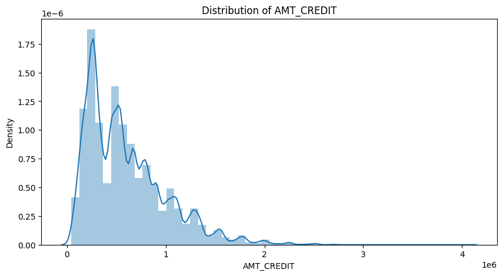

```python
plt.figure(figsize=(10,5))
plt.title("Distribution of AMT_CREDIT")
sns.distplot(application_train["AMT_CREDIT"])
plt.show()
```

### Distribution of AMT_INCOME_TOTAL

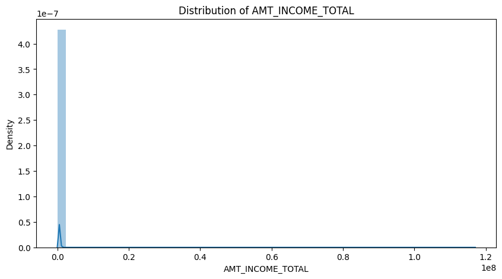

```python
plt.figure(figsize=(10,5))
plt.title("Distribution of AMT_INCOME_TOTAL")
sns.distplot(application_train["AMT_INCOME_TOTAL"].dropna())
plt.show()
```

### Distribution of AMT_GOODS_PRICE

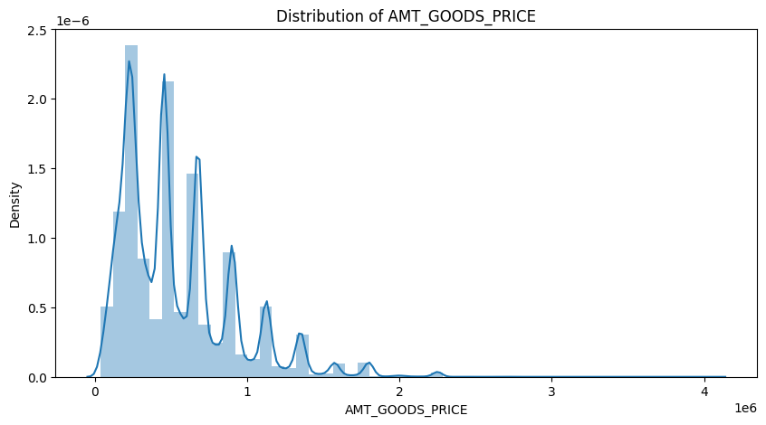

```python
plt.figure(figsize=(10,5))
plt.title("Distribution of AMT_GOODS_PRICE")
sns.distplot(application_train["AMT_GOODS_PRICE"].dropna())
plt.show()
```

### Distribution of target (balanced or imbalanced)

```python
temp = application_train["TARGET"].value_counts()
target_count = pd.DataFrame({'labels': temp.index,
                            'values': temp.values})
target_count
```

|  | labels | values |
| --- | --- | --- |
| 0 | 0 | 282686 |
| 1 | 1 | 24825 |

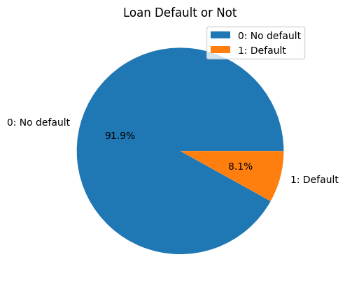

```python
default = ["0: No default", "1: Default"]
plt.pie(temp, labels =default, autopct='%1.1f%%')
plt.title("Loan Default or Not")
plt.legend()
plt.show()
```

### Distribution of Occupation Type

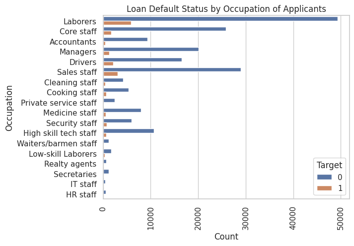

```python
sns.set(style="whitegrid")
temp_occ = sns.countplot(y='OCCUPATION_TYPE', hue = 'TARGET',
                       data = application_train)
plt.xlabel('Count')
plt.xticks(rotation = 90)
plt.ylabel('Occupation')
plt.title('Loan Default Status by Occupation of Applicants')
plt.legend(title = 'Target')
plt.show()
```

### Types of Organizations

[figure not shown]

```python
sns.set(style="whitegrid")
temp_occ = sns.countplot(y='ORGANIZATION_TYPE', hue = 'TARGET',
                       data = application_train)
plt.xlabel('Count')
plt.xticks(rotation = 90)
plt.ylabel('Organization Type')
plt.title('Loan Default Status by Organization Type')
plt.legend(title = 'Target')
plt.figure(figsize=(10, 20))
plt.show()
```

### Old or New Client

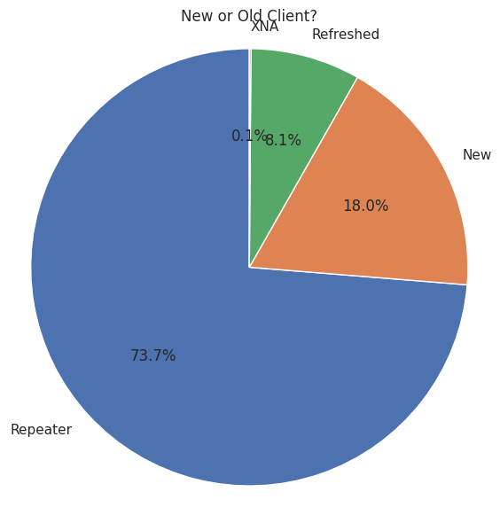

```python
temp_prev2 = pd.DataFrame({'labels': previous_application["NAME_CLIENT_TYPE"].value_counts().index,
                   'values': previous_application["NAME_CLIENT_TYPE"].value_counts().values})
plt.figure(figsize=(7, 7))
plt.pie(temp_prev2["values"],labels=temp_prev2["labels"], autopct='%1.1f%%', startangle=90)
plt.title("New or Old Client?")
plt.axis('equal')
plt.show()
```

### Did the client requested insurance?

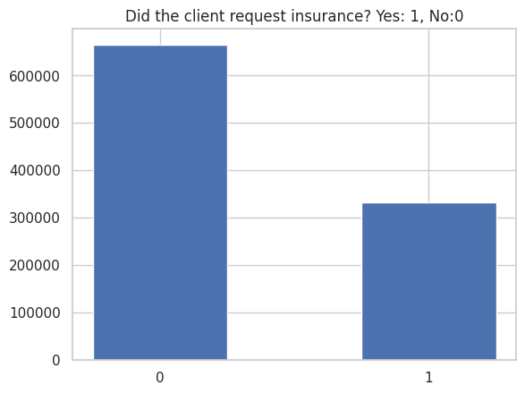

```python
temp_prev3 = pd.DataFrame({'labels': previous_application["NFLAG_INSURED_ON_APPROVAL"].value_counts().index,
                   'values': previous_application["NFLAG_INSURED_ON_APPROVAL"].value_counts()
                  })
plt.bar(temp_prev3["labels"], temp_prev3["values"], width=0.5)
plt.xticks([0, 1])
plt.title("Did the client request insurance? Yes: 1, No:0")
plt.show()
```

## Correlation

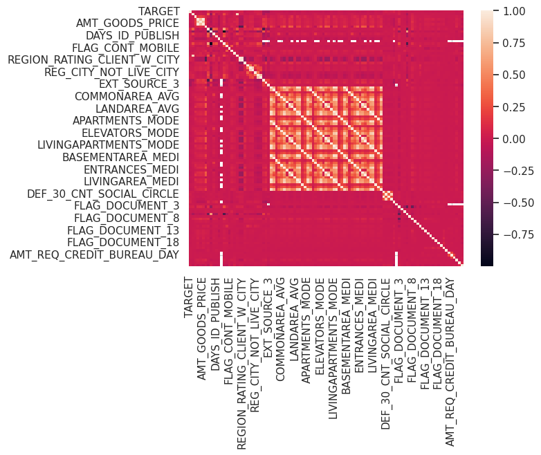

```python
cor = application_train.drop('SK_ID_CURR',axis=1).corr()
sns.heatmap(cor)
plt.show()
```

## Discussing EDA Findings

We begin by reviewing the first few rows of each table to look at what data is available to us. We then must review what type of data it is, whether it is already cleaned, and wether or not we can actually make use of the fields given their missing or outlier data.

In this data, we have a mixed bag of information. Many columns are fully complete, many have more NAs than datapoints. Thankfully, the columns that do not have missing data will be important to our model; however, we will need to clean several columns for our model because of their NA values or their outlier data that is more erroneous than a true outlier.

## 4. Data Cleaning

```python
from sklearn import preprocessing
from sklearn.preprocessing import LabelEncoder

train_cop = application_train.copy()
test_cop = application_test.copy()

def categorical_col(df):
  cats = [col for col in list(df.columns) if df[col].dtypes == 'object']
  return cats

train_cat = categorical_col(train_cop)

for col in train_cat:
  le = preprocessing.LabelEncoder()
  le.fit(list(train_cop[col].values.astype('str')) + list(test_cop[col].values.astype('str')))
  train_cop[col] = le.transform(list(train_cop[col].values.astype('str')))
  test_cop[col] = le.transform(list(test_cop[col].values.astype('str')))

train_cop.head()
```

|  | SK_ID_CURR | TARGET | NAME_CONTRACT_TYPE | CODE_GENDER | FLAG_OWN_CAR | FLAG_OWN_REALTY | CNT_CHILDREN | AMT_INCOME_TOTAL | AMT_CREDIT | AMT_ANNUITY | ... | FLAG_DOCUMENT_18 | FLAG_DOCUMENT_19 | FLAG_DOCUMENT_20 | FLAG_DOCUMENT_21 | AMT_REQ_CREDIT_BUREAU_HOUR | AMT_REQ_CREDIT_BUREAU_DAY | AMT_REQ_CREDIT_BUREAU_WEEK | AMT_REQ_CREDIT_BUREAU_MON | AMT_REQ_CREDIT_BUREAU_QRT | AMT_REQ_CREDIT_BUREAU_YEAR |
| --- | --- | --- | --- | --- | --- | --- | --- | --- | --- | --- | --- | --- | --- | --- | --- | --- | --- | --- | --- | --- | --- |
| 0 | 100002 | 1 | 0 | 1 | 0 | 1 | 0 | 202500.0 | 406597.5 | 24700.5 | ... | 0 | 0 | 0 | 0 | 0.0 | 0.0 | 0.0 | 0.0 | 0.0 | 1.0 |
| 1 | 100003 | 0 | 0 | 0 | 0 | 0 | 0 | 270000.0 | 1293502.5 | 35698.5 | ... | 0 | 0 | 0 | 0 | 0.0 | 0.0 | 0.0 | 0.0 | 0.0 | 0.0 |
| 2 | 100004 | 0 | 1 | 1 | 1 | 1 | 0 | 67500.0 | 135000.0 | 6750.0 | ... | 0 | 0 | 0 | 0 | 0.0 | 0.0 | 0.0 | 0.0 | 0.0 | 0.0 |
| 3 | 100006 | 0 | 0 | 0 | 0 | 1 | 0 | 135000.0 | 312682.5 | 29686.5 | ... | 0 | 0 | 0 | 0 | NaN | NaN | NaN | NaN | NaN | NaN |
| 4 | 100007 | 0 | 0 | 1 | 0 | 1 | 0 | 121500.0 | 513000.0 | 21865.5 | ... | 0 | 0 | 0 | 0 | 0.0 | 0.0 | 0.0 | 0.0 | 0.0 | 0.0 |

5 rows × 122 columns

## 5. Missing Data

```python
count_missing = train_cop.isnull().sum().sort_values(ascending = False)
Total =train_cop.isnull().count()
percent = (train_cop.isnull().sum()/train_cop.isnull().count()*100).sort_values(ascending = False)
missing_application_train_data  = pd.concat([count_missing,Total,np.round(percent, 2)],axis=1,keys=['Count of  Missing Values','Total','Percent'])
print(missing_application_train_data.head(60))
##percent = (train_cop.isnull().sum()/train_cop.isnull().count()*100).sort_values(ascending = False)
##missing_application_train_data = pd.concat([count_missing, Total, np.round(percent, 2)], axis=1, keys=['Count of Missing Values', 'Total', 'Percent'])
##columns_to_drop = missing_application_train_data[missing_application_train_data['Percent'] > 50].index
##application_train_dropped = train_cop.drop(columns_to_drop, axis=1)
##print(application_train_dropped.shape)
##new_set = application_train_dropped
```

```
                              Count of  Missing Values   Total  Percent
COMMONAREA_AVG                                  214865  307511    69.87
COMMONAREA_MEDI                                 214865  307511    69.87
COMMONAREA_MODE                                 214865  307511    69.87
NONLIVINGAPARTMENTS_MODE                        213514  307511    69.43
NONLIVINGAPARTMENTS_AVG                         213514  307511    69.43
NONLIVINGAPARTMENTS_MEDI                        213514  307511    69.43
LIVINGAPARTMENTS_MODE                           210199  307511    68.35
LIVINGAPARTMENTS_MEDI                           210199  307511    68.35
LIVINGAPARTMENTS_AVG                            210199  307511    68.35
FLOORSMIN_MEDI                                  208642  307511    67.85
FLOORSMIN_MODE                                  208642  307511    67.85
FLOORSMIN_AVG                                   208642  307511    67.85
YEARS_BUILD_MEDI                                204488  307511    66.50
YEARS_BUILD_MODE                                204488  307511    66.50
YEARS_BUILD_AVG                                 204488  307511    66.50
OWN_CAR_AGE                                     202929  307511    65.99
LANDAREA_AVG                                    182590  307511    59.38
LANDAREA_MEDI                                   182590  307511    59.38
LANDAREA_MODE                                   182590  307511    59.38
BASEMENTAREA_AVG                                179943  307511    58.52
BASEMENTAREA_MEDI                               179943  307511    58.52
BASEMENTAREA_MODE                               179943  307511    58.52
EXT_SOURCE_1                                    173378  307511    56.38
NONLIVINGAREA_MEDI                              169682  307511    55.18
NONLIVINGAREA_MODE                              169682  307511    55.18
NONLIVINGAREA_AVG                               169682  307511    55.18
ELEVATORS_MEDI                                  163891  307511    53.30
ELEVATORS_AVG                                   163891  307511    53.30
ELEVATORS_MODE                                  163891  307511    53.30
APARTMENTS_MEDI                                 156061  307511    50.75
APARTMENTS_AVG                                  156061  307511    50.75
APARTMENTS_MODE                                 156061  307511    50.75
ENTRANCES_AVG                                   154828  307511    50.35
ENTRANCES_MODE                                  154828  307511    50.35
ENTRANCES_MEDI                                  154828  307511    50.35
LIVINGAREA_MODE                                 154350  307511    50.19
LIVINGAREA_AVG                                  154350  307511    50.19
LIVINGAREA_MEDI                                 154350  307511    50.19
FLOORSMAX_MODE                                  153020  307511    49.76
FLOORSMAX_AVG                                   153020  307511    49.76
FLOORSMAX_MEDI                                  153020  307511    49.76
YEARS_BEGINEXPLUATATION_AVG                     150007  307511    48.78
YEARS_BEGINEXPLUATATION_MODE                    150007  307511    48.78
YEARS_BEGINEXPLUATATION_MEDI                    150007  307511    48.78
TOTALAREA_MODE                                  148431  307511    48.27
EXT_SOURCE_3                                     60965  307511    19.83
AMT_REQ_CREDIT_BUREAU_HOUR                       41519  307511    13.50
AMT_REQ_CREDIT_BUREAU_DAY                        41519  307511    13.50
AMT_REQ_CREDIT_BUREAU_WEEK                       41519  307511    13.50
AMT_REQ_CREDIT_BUREAU_MON                        41519  307511    13.50
AMT_REQ_CREDIT_BUREAU_QRT                        41519  307511    13.50
AMT_REQ_CREDIT_BUREAU_YEAR                       41519  307511    13.50
OBS_30_CNT_SOCIAL_CIRCLE                          1021  307511     0.33
DEF_30_CNT_SOCIAL_CIRCLE                          1021  307511     0.33
OBS_60_CNT_SOCIAL_CIRCLE                          1021  307511     0.33
DEF_60_CNT_SOCIAL_CIRCLE                          1021  307511     0.33
EXT_SOURCE_2                                       660  307511     0.21
AMT_GOODS_PRICE                                    278  307511     0.09
AMT_ANNUITY                                         12  307511     0.00
CNT_FAM_MEMBERS                                      2  307511     0.00
```

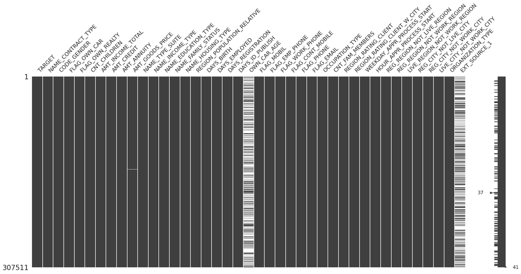

```python
app_train_set1= train_cop.iloc[:,1:42]
msno.matrix(app_train_set1)
```

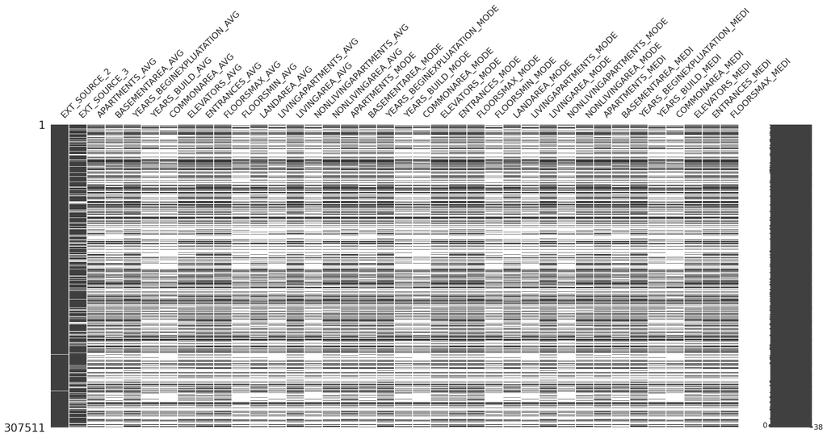

```python
app_train_set2= train_cop.iloc[:,42:80]
msno.matrix(app_train_set2)
```

##### By plotting the columns as above, it is easier for us to identify the columns with most missing values. Which leads us in identifying which columns are most relevant to use for the modeling process. This is a conscious decision as it is not practical to "fix" every single column of data that we ever work with. There is a real cost to doing so and if a column of data will not make a real impact on a model, it is prudent to actively decide if it should be cleaned or not.

```python
test_set = test_cop.drop(["SK_ID_CURR"], axis=1)
SK_ID_CURR = test_cop["SK_ID_CURR"]
x_train = train_cop.drop(['SK_ID_CURR', 'TARGET'],axis=1)
y_target = train_cop.TARGET
```

## 6. Modeling Process

##### We have cleaned and prepared our data and we are now ready to begin training various models as we explore which model is best. We have tried different types of models.

#### Outliers - Identifcation and handling

```python
# Identification of Column types
application_train_copy= application_train.copy()
application_test_copy= application_test.copy()
numeric_columns = application_train_copy.select_dtypes(include=['int', 'float']).columns
numeric_columns_test = application_test_copy.select_dtypes(include=['int', 'float']).columns

# Find columns with object/string data type
object_columns = application_train_copy.select_dtypes(include=['object']).columns
object_columns_test = application_test_copy.select_dtypes(include=['object']).columns

binary_columns = []
for column in application_train_copy.columns:
    unique_values = application_train_copy[column].value_counts()
    if set(unique_values.index).issubset([0, 1]):
        binary_columns.append(column)

binary_columns_test = []
for column in application_test_copy.columns:
    unique_values = application_test_copy[column].value_counts()
    if set(unique_values.index).issubset([0, 1]):
        binary_columns.append(column)
```

```python
# Function for removing Outliers
def remove_outliers_zscore(df, threshold=3):
    # Calculate the z-scores for each column in the dataframe
    z_scores = np.abs(df - df.mean()) / df.std()

    # Identify the rows that are outliers
    outlier_mask = z_scores > threshold

    # Drop the outlier rows from the dataframe
    df = df.loc[~outlier_mask]

    return df
```

```python
#Removal of outliers from numeric columns( excluding binary columns)
for column in numeric_columns:
  if column not in binary_columns:
    application_train_copy[column]= remove_outliers_zscore(application_train_copy[column], threshold=3)
    application_test_copy[column]= remove_outliers_zscore(application_test_copy[column], threshold=3)
```

## Data Imputation

```python
from sklearn.impute import SimpleImputer

numeric_columns = application_train_copy.select_dtypes(include='number').columns
categorical_columns = application_train_copy.select_dtypes(include='object').columns

numeric_imputer = SimpleImputer(strategy='median')
application_train_copy[numeric_columns] = numeric_imputer.fit_transform(application_train_copy[numeric_columns])

# Impute missing values in categorical columns with most frequent
categorical_imputer = SimpleImputer(strategy='most_frequent')
application_train_copy[categorical_columns] = categorical_imputer.fit_transform(application_train_copy[categorical_columns])
```

## Data Encoding

```python
# Identify categorical columns
categorical_columns = application_train_copy.select_dtypes(include=['object']).columns

# Perform factorization on categorical columns
application_train_encoded = application_train_copy.copy()
application_train_encoded[categorical_columns] = application_train_encoded[categorical_columns].apply(lambda x: pd.factorize(x)[0])

# Display the encoded DataFrame
application_train_encoded.head()
```

|  | SK_ID_CURR | TARGET | NAME_CONTRACT_TYPE | CODE_GENDER | FLAG_OWN_CAR | FLAG_OWN_REALTY | CNT_CHILDREN | AMT_INCOME_TOTAL | AMT_CREDIT | AMT_ANNUITY | ... | FLAG_DOCUMENT_18 | FLAG_DOCUMENT_19 | FLAG_DOCUMENT_20 | FLAG_DOCUMENT_21 | AMT_REQ_CREDIT_BUREAU_HOUR | AMT_REQ_CREDIT_BUREAU_DAY | AMT_REQ_CREDIT_BUREAU_WEEK | AMT_REQ_CREDIT_BUREAU_MON | AMT_REQ_CREDIT_BUREAU_QRT | AMT_REQ_CREDIT_BUREAU_YEAR |
| --- | --- | --- | --- | --- | --- | --- | --- | --- | --- | --- | --- | --- | --- | --- | --- | --- | --- | --- | --- | --- | --- |
| 0 | 100002.0 | 1.0 | 0 | 0 | 0 | 0 | 0.0 | 202500.0 | 406597.5 | 24700.5 | ... | 0.0 | 0.0 | 0.0 | 0.0 | 0.0 | 0.0 | 0.0 | 0.0 | 0.0 | 1.0 |
| 1 | 100003.0 | 0.0 | 0 | 1 | 0 | 1 | 0.0 | 270000.0 | 1293502.5 | 35698.5 | ... | 0.0 | 0.0 | 0.0 | 0.0 | 0.0 | 0.0 | 0.0 | 0.0 | 0.0 | 0.0 |
| 2 | 100004.0 | 0.0 | 1 | 0 | 1 | 0 | 0.0 | 67500.0 | 135000.0 | 6750.0 | ... | 0.0 | 0.0 | 0.0 | 0.0 | 0.0 | 0.0 | 0.0 | 0.0 | 0.0 | 0.0 |
| 3 | 100006.0 | 0.0 | 0 | 1 | 0 | 0 | 0.0 | 135000.0 | 312682.5 | 29686.5 | ... | 0.0 | 0.0 | 0.0 | 0.0 | 0.0 | 0.0 | 0.0 | 0.0 | 0.0 | 1.0 |
| 4 | 100007.0 | 0.0 | 0 | 0 | 0 | 0 | 0.0 | 121500.0 | 513000.0 | 21865.5 | ... | 0.0 | 0.0 | 0.0 | 0.0 | 0.0 | 0.0 | 0.0 | 0.0 | 0.0 | 0.0 |

5 rows × 122 columns

## Regression - Model

### Regression Without Interactions

```python
from sklearn.linear_model import LogisticRegression
from sklearn.model_selection import train_test_split
from sklearn.metrics import accuracy_score, roc_auc_score

X= application_train_encoded.drop('TARGET', axis=1)
Y= application_train_encoded.TARGET

# Split the data into training and testing sets
X_train, X_test, Y_train, Y_test = train_test_split( X.loc[:, ~X.columns.isin(['CAR_AGE_BINS'])], Y, test_size=0.35, random_state=0, stratify= Y)

Y_train.sum()
Y_test.sum()

print('X_train', X_train.shape)
print('X_test', X_test.shape)
print('Y_train', Y_train.shape)
print('Y_test', Y_test.shape)

# Initialize the logistic regression model
logreg_reg = LogisticRegression()

# Fit the model to the training data
logreg_reg.fit(X_train, Y_train)

# Predict the target variable for the test data
y_pred = logreg_reg.predict(X_test)

# Calculate the accuracy of the model
accuracy = accuracy_score(Y_test, y_pred)
print("Accuracy:", accuracy)
auc_roc = roc_auc_score(Y_test, logreg_reg.predict_proba(X_test)[:, 1])
print("AUC-ROC:", auc_roc)
```

```
X_train (199882, 121)
X_test (107629, 121)
Y_train (199882,)
Y_test (107629,)
Accuracy: 0.919268970258945
AUC-ROC: 0.6081676485442433
```

##### The logistic regression model achieved an accuracy of 91.9% on the testing data, indicating that it correctly classified the majority of instances. The area under the ROC curve (AUC-ROC) was found to be 0.608, suggesting a fair level of predictive performance for the model.

##### Overall, the logistic regression model showed decent accuracy in predicting the target variable based on the given dataset. However, it is important to note that the AUC-ROC value indicates room for improvement, suggesting that the model's performance may not be optimal. Further exploration, feature engineering, or trying different models could potentially enhance the predictive performance.

## Data Normalisation

```python
import pandas as pd
from sklearn.preprocessing import MinMaxScaler

Train_normalised= application_train_encoded.copy()
# Create a DataFrame from the dictionary

numeric_cols = Train_normalised.select_dtypes(include=['int', 'float']).columns

# Create an instance of MinMaxScaler
scaler = MinMaxScaler()

# Apply normalization to the selected columns
Train_normalised[numeric_cols] = scaler.fit_transform(Train_normalised[numeric_cols])

Train_normalised.head()
```

|  | SK_ID_CURR | TARGET | NAME_CONTRACT_TYPE | CODE_GENDER | FLAG_OWN_CAR | FLAG_OWN_REALTY | CNT_CHILDREN | AMT_INCOME_TOTAL | AMT_CREDIT | AMT_ANNUITY | ... | FLAG_DOCUMENT_18 | FLAG_DOCUMENT_19 | FLAG_DOCUMENT_20 | FLAG_DOCUMENT_21 | AMT_REQ_CREDIT_BUREAU_HOUR | AMT_REQ_CREDIT_BUREAU_DAY | AMT_REQ_CREDIT_BUREAU_WEEK | AMT_REQ_CREDIT_BUREAU_MON | AMT_REQ_CREDIT_BUREAU_QRT | AMT_REQ_CREDIT_BUREAU_YEAR |
| --- | --- | --- | --- | --- | --- | --- | --- | --- | --- | --- | --- | --- | --- | --- | --- | --- | --- | --- | --- | --- | --- |
| 0 | 0.000000 | 1.0 | 0.0 | 0.0 | 0.0 | 0.0 | 0.0 | 0.207607 | 0.205338 | 0.334725 | ... | 0.0 | 0.0 | 0.0 | 0.0 | 0.0 | 0.0 | 0.0 | 0.0 | 0.0 | 0.142857 |
| 1 | 0.000003 | 0.0 | 0.0 | 0.5 | 0.0 | 1.0 | 0.0 | 0.286846 | 0.708980 | 0.494193 | ... | 0.0 | 0.0 | 0.0 | 0.0 | 0.0 | 0.0 | 0.0 | 0.0 | 0.0 | 0.000000 |
| 2 | 0.000006 | 0.0 | 1.0 | 0.0 | 1.0 | 0.0 | 0.0 | 0.049128 | 0.051108 | 0.074449 | ... | 0.0 | 0.0 | 0.0 | 0.0 | 0.0 | 0.0 | 0.0 | 0.0 | 0.0 | 0.000000 |
| 3 | 0.000011 | 0.0 | 0.0 | 0.5 | 0.0 | 0.0 | 0.0 | 0.128368 | 0.152007 | 0.407021 | ... | 0.0 | 0.0 | 0.0 | 0.0 | 0.0 | 0.0 | 0.0 | 0.0 | 0.0 | 0.142857 |
| 4 | 0.000014 | 0.0 | 0.0 | 0.0 | 0.0 | 0.0 | 0.0 | 0.112520 | 0.265760 | 0.293619 | ... | 0.0 | 0.0 | 0.0 | 0.0 | 0.0 | 0.0 | 0.0 | 0.0 | 0.0 | 0.000000 |

5 rows × 122 columns

### Regression with Normalised Data

```python
from sklearn.linear_model import LogisticRegression
from sklearn.model_selection import train_test_split
from sklearn.metrics import accuracy_score, roc_auc_score

Y1= Train_normalised.TARGET
X1= Train_normalised.drop('TARGET', axis=1)


# Split the data into training and testing sets
X1_train, X1_test, Y1_train, Y1_test = train_test_split( X1, Y1, test_size=0.30, random_state=0, stratify= Y)

Y1_train.sum()
Y1_test.sum()

print('X1_train', X1_train.shape)
print('X1_test', X1_test.shape)
print('Y1_train', Y1_train.shape)
print('Y1_test', Y1_test.shape)

# Initialize the logistic regression model
logreg_normalised = LogisticRegression()

# Fit the model to the training data
logreg_normalised.fit(X1_train, Y1_train)

# Predict the target variable for the test data
y1_pred = logreg_normalised.predict(X1_test)

# Calculate the accuracy of the model
accuracy = accuracy_score(Y1_test, y1_pred)
print("Accuracy:", accuracy)
```

```
X1_train (215257, 121)
X1_test (92254, 121)
Y1_train (215257,)
Y1_test (92254,)
Accuracy: 0.9192121750818393
```

##### The logistic regression model achieved an accuracy of 91.9% on the testing data, indicating that it correctly classified the majority of instances.

# Feature Importance using XGBoost

```python
from xgboost import XGBClassifier
from xgboost import plot_importance
from sklearn.model_selection import GridSearchCV
parameters = {
    'n_estimators': 100,
    'max_depth': 3,
    'random_state': 8,
    'n_jobs': -1
}
xgb_model = xgb.XGBClassifier(**parameters)
xgb_model.fit(x_train, y_target)
```

```
XGBClassifier(base_score=None, booster=None, callbacks=None,
              colsample_bylevel=None, colsample_bynode=None,
              colsample_bytree=None, early_stopping_rounds=None,
              enable_categorical=False, eval_metric=None, feature_types=None,
              gamma=None, gpu_id=None, grow_policy=None, importance_type=None,
              interaction_constraints=None, learning_rate=None, max_bin=None,
              max_cat_threshold=None, max_cat_to_onehot=None,
              max_delta_step=None, max_depth=3, max_leaves=None,
              min_child_weight=None, missing=nan, monotone_constraints=None,
              n_estimators=100, n_jobs=-1, num_parallel_tree=None,
              predictor=None, random_state=8, ...)
```

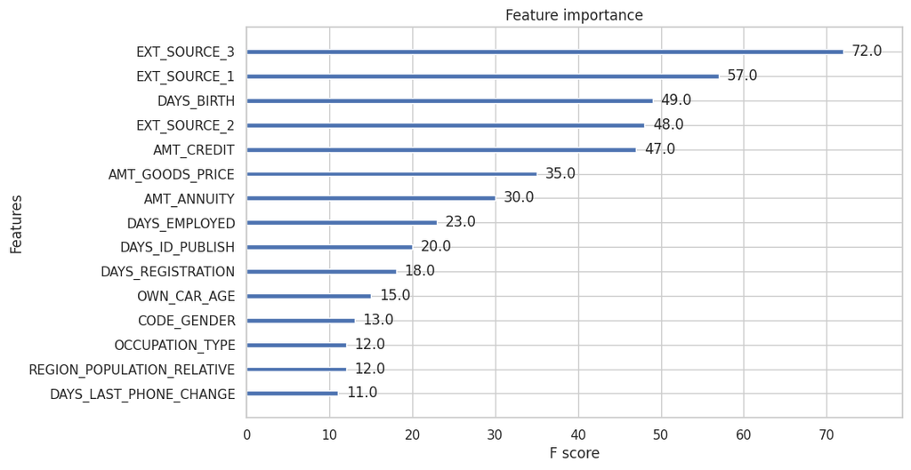

```python
fig, ax = plt.subplots(figsize=(10, 6))
plot_importance(xgb_model, ax=ax, max_num_features=15)
plt.show()
```

```python
mod_pred = xgb_model.predict(test_set)
```

```python
from sklearn.metrics import accuracy_score, precision_score, recall_score, f1_score, roc_auc_score, confusion_matrix

#reduce target as test dataset set is only 48744
t_target = y_target[:48744]

accuracy = accuracy_score(t_target, mod_pred)
print("Accuracy: ", accuracy)

precision = precision_score(t_target, mod_pred)
print("Precision:", precision)

recall = recall_score(t_target, mod_pred)
print("Recall:", recall)

f1 = f1_score(t_target, mod_pred)
print("F1-score:", f1)

roc_auc = roc_auc_score(t_target, mod_pred)
print("ROC-AUC:", roc_auc)

confusion_mat = confusion_matrix(t_target, mod_pred)
print("Confusion Matrix:")
print(confusion_mat)
```

```
Accuracy:  0.9175077958312818
Precision: 0.06481481481481481
Recall: 0.0017825311942959
F1-score: 0.003469640644361834
ROC-AUC: 0.49976446103637856
Confusion Matrix:
[[44716   101]
 [ 3920     7]]
```

```python
k_pred = pd.DataFrame({'SK_ID_CURR': SK_ID_CURR, 'TARGET': mod_pred})
k_pred.shape
k_pred.to_csv('/content/drive/MyDrive/home-credit-default-risk/k_pred.csv', index=False)
```

# LGBM Classifier Modeling

##### A LightGBM model is trained on the training set using gradient boosting algorithms. A basic decision tree model and Random Forest models were tested; however, GBM models performed more efficiently. They outperformed the basic decision tree quite handily and they, so far, have been much faster than Random Forest models. Therefore, as we have not see any other disadvantages with GBM that other models perform better, we have proceeded with using GBM models.

```python
from lightgbm import LGBMClassifier
sample = train_cop.sample(n=48744, random_state = 8)
y_target = sample.TARGET
x_train = sample.drop(['SK_ID_CURR', 'TARGET'],axis=1)
```

```python
lgb_mod = LGBMClassifier()
lgb_mod.fit(x_train, y_target)
```

```
LGBMClassifier()
```

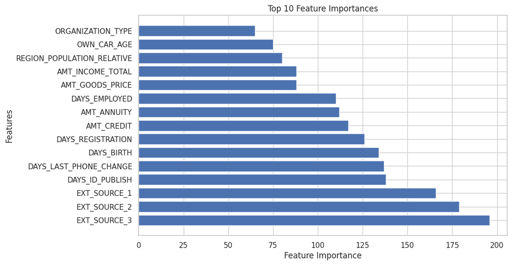

```python
lgb_features = lgb_mod.feature_importances_
feature_name = x_train.columns
# Sort feature importances in descending order
sorted_idx = np.argsort(lgb_features)[::-1]
topLGB_features = feature_name[sorted_idx][:15]
topLGB_importances = lgb_features[sorted_idx][:15]

plt.figure(figsize=(10, 6))
plt.barh(range(len(topLGB_features)), topLGB_importances, align='center')
plt.yticks(range(len(topLGB_features)), topLGB_features)
plt.xlabel('Feature Importance')
plt.ylabel('Features')
plt.title('Top 10 Feature Importances')
plt.show()
```

##### From the above plot we obsevere that EXT_SOURCE_3 is the top most important feature along with top 10 features.

```python
lgb_pred = lgb_mod.predict(test_set)

accuracy = accuracy_score(y_target, lgb_pred)
precision = precision_score(y_target, lgb_pred)
recall = recall_score(y_target, lgb_pred)
f1 = f1_score(y_target, lgb_pred)
roc_auc = roc_auc_score(y_target, lgb_pred)
confusion_mat = confusion_matrix(y_target, lgb_pred)

print(f"Accuracy: {accuracy}")
print(f"Precision: {precision}")
print(f"Recall: {recall}")
print(f"F1-score: {f1}")
print(f"ROC-AUC: {roc_auc}")
print("Confusion Matrix:")
print(confusion_mat)
```

```
Accuracy: 0.9174257344493681
Precision: 0.09090909090909091
Recall: 0.0028018339276617422
F1-score: 0.0054361255250803065
ROC-AUC: 0.5001737314580073
Confusion Matrix:
[[44708   110]
 [ 3915    11]]
```

```python
lgbPrediction = pd.DataFrame({'SK_ID_CURR': SK_ID_CURR, 'TARGET': lgb_pred})
lgbPrediction.shape
lgbPrediction.to_csv('/content/drive/MyDrive/home-credit-default-risk/lgbPrediction.csv', index=False)
```

# Hyperparameter Tunning Using GridSearchCV

```python
pars = {'n_estimators': [100, 200, 500], 'max_depth': [3, 5, 8], 'random_state': [8]}
grid_search = GridSearchCV(lgb_mod, pars, cv=5)
grid_search.fit(x_train, y_target)
best_params = grid_search.best_params_
```

```python
print(f"Best Parameters:{best_params}")
best_model = grid_search.best_estimator_
print(f"Best Estimator:{best_model}")
```

```
Best Parameters:{'max_depth': 5, 'n_estimators': 100, 'random_state': 8}
Best Estimator:LGBMClassifier(max_depth=5, random_state=8)
```

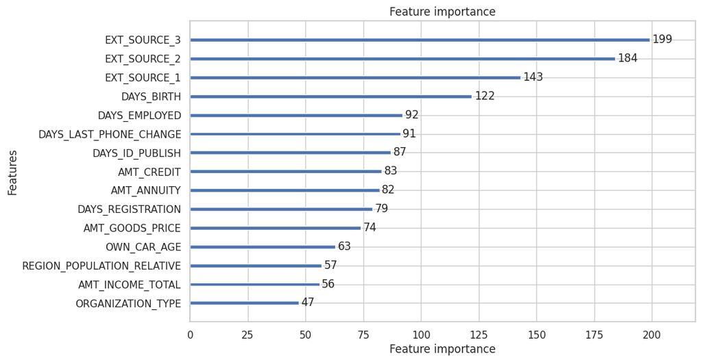

```python
best_model.fit(x_train, y_target)
lgb.plot_importance(best_model, max_num_features = 15, figsize=(10, 6))
plt.show()
```

```python
print(x_train.shape)
y_target.shape
```

```
(48744, 120)
```

```
(48744,)
```

```python
bestModLGB_pred = best_model.predict(test_set)

accuracy = accuracy_score(t_target, bestModLGB_pred)
precision = precision_score(t_target, bestModLGB_pred)
recall = recall_score(t_target, bestModLGB_pred)
f1 = f1_score(t_target, lgb_pred)
roc_auc = roc_auc_score(t_target, bestModLGB_pred)
confusion_mat = confusion_matrix(t_target, bestModLGB_pred)

print(f"Accuracy: {accuracy}")
print(f"Precision: {precision}")
print(f"Recall: {recall}")
print(f"F1-score: {f1}")
print(f"ROC-AUC: {roc_auc}")
print("Confusion Matrix:")
print(confusion_mat)
```

```
Accuracy: 0.9178565567044149
Precision: 0.07692307692307693
Recall: 0.0017825311942959
F1-score: 0.0029644268774703555
ROC-AUC: 0.4999541212099734
Confusion Matrix:
[[44733    84]
 [ 3920     7]]
```

```python
lgbPrediction2 = pd.DataFrame({'SK_ID_CURR': SK_ID_CURR, 'TARGET': bestModLGB_pred})
lgbPrediction2.shape
lgbPrediction2.to_csv('/content/drive/MyDrive/home-credit-default-risk/lgbPrediction_grid.csv', index=False)
```

# Preprocessing and Feature Engineering

```python
data = train_cop.drop(["TARGET"], axis=1)
data = data.append(test_set).reset_index()
```

```python
data.shape
```

```
(356255, 122)
```

```python
for col in previous_application.columns:
    if previous_application[col].dtypes==object:
        LE = LabelEncoder()
        previous_application[col] = LE.fit_transform(list(previous_application[col].values.astype('str')))
aggregations = {
        'AMT_ANNUITY': ['min', 'max', 'mean'],
        'AMT_APPLICATION': ['min', 'max', 'mean'],
        'AMT_CREDIT': ['min', 'max', 'mean'],
        'AMT_DOWN_PAYMENT': ['min', 'max', 'mean'],
        'AMT_GOODS_PRICE': ['min', 'max', 'mean'],
        'HOUR_APPR_PROCESS_START': ['min', 'max', 'mean'],
        'RATE_DOWN_PAYMENT': ['min', 'max', 'mean'],
        'DAYS_DECISION': ['min', 'max', 'mean'],
        'CNT_PAYMENT': ['mean', 'var'],
    }
prev_agg = previous_application.groupby('SK_ID_CURR').agg({**aggregations})
print(prev_agg)
prev_agg.columns = pd.Index(['PREV_' + col[0] + "_" + col[1].upper() for col in prev_agg.columns.tolist()])
prev_agg.head()
```

```
           AMT_ANNUITY                          AMT_APPLICATION             \
                   min        max          mean             min        max
SK_ID_CURR
100001        3951.000   3951.000   3951.000000         24835.5    24835.5
100002        9251.775   9251.775   9251.775000        179055.0   179055.0
100003        6737.310  98356.995  56553.990000         68809.5   900000.0
100004        5357.250   5357.250   5357.250000         24282.0    24282.0
100005        4813.200   4813.200   4813.200000             0.0    44617.5
...                ...        ...           ...             ...        ...
456251        6605.910   6605.910   6605.910000         40455.0    40455.0
456252       10074.465  10074.465  10074.465000         57595.5    57595.5
456253        3973.095   5567.715   4770.405000         19413.0    28912.5
456254        2296.440  19065.825  10681.132500         18846.0   223789.5
456255        2250.000  54022.140  20775.391875         45000.0  1170000.0

                       AMT_CREDIT                       AMT_DOWN_PAYMENT  ...  \
                  mean        min        max       mean              min  ...
SK_ID_CURR                                                                ...
100001       24835.500    23787.0    23787.0   23787.00           2520.0  ...
100002      179055.000   179055.0   179055.0  179055.00              0.0  ...
100003      435436.500    68053.5  1035882.0  484191.00              0.0  ...
100004       24282.000    20106.0    20106.0   20106.00           4860.0  ...
100005       22308.750        0.0    40153.5   20076.75           4464.0  ...
...                ...        ...        ...        ...              ...  ...
456251       40455.000    40455.0    40455.0   40455.00              0.0  ...
456252       57595.500    56821.5    56821.5   56821.50           3456.0  ...
456253       24162.750    13945.5    27306.0   20625.75           2893.5  ...
456254      121317.750    21456.0   247423.5  134439.75              0.0  ...
456255      362770.875    45000.0  1271929.5  424431.00              0.0  ...

           HOUR_APPR_PROCESS_START            RATE_DOWN_PAYMENT            \
                               max       mean               min       max
SK_ID_CURR
100001                          13  13.000000          0.104326  0.104326
100002                           9   9.000000          0.000000  0.000000
100003                          17  14.666667          0.000000  0.100061
100004                           5   5.000000          0.212008  0.212008
100005                          11  10.500000          0.108964  0.108964
...                            ...        ...               ...       ...
456251                          17  17.000000          0.000000  0.000000
456252                          10  10.000000          0.062443  0.062443
456253                          12  11.500000          0.104349  0.324284
456254                          18  15.000000          0.000000  0.000000
456255                          18  14.625000          0.000000  0.098524

                     DAYS_DECISION                 CNT_PAYMENT
                mean           min   max      mean        mean         var
SK_ID_CURR
100001      0.104326         -1740 -1740 -1740.000        8.00         NaN
100002      0.000000          -606  -606  -606.000       24.00         NaN
100003      0.050030         -2341  -746 -1305.000       10.00   12.000000
100004      0.212008          -815  -815  -815.000        4.00         NaN
100005      0.108964          -757  -315  -536.000       12.00         NaN
...              ...           ...   ...       ...         ...         ...
456251      0.000000          -273  -273  -273.000        8.00         NaN
456252      0.062443         -2497 -2497 -2497.000        6.00         NaN
456253      0.214316         -2851 -1909 -2380.000        5.00    2.000000
456254      0.000000          -322  -277  -299.500       15.00    2.000000
456255      0.064780          -991  -171  -587.625       21.75  369.642857

[338857 rows x 26 columns]
```

| SK_ID_CURR | PREV_AMT_ANNUITY_MIN | PREV_AMT_ANNUITY_MAX | PREV_AMT_ANNUITY_MEAN | PREV_AMT_APPLICATION_MIN | PREV_AMT_APPLICATION_MAX | PREV_AMT_APPLICATION_MEAN | PREV_AMT_CREDIT_MIN | PREV_AMT_CREDIT_MAX | PREV_AMT_CREDIT_MEAN | PREV_AMT_DOWN_PAYMENT_MIN | ... | PREV_HOUR_APPR_PROCESS_START_MAX | PREV_HOUR_APPR_PROCESS_START_MEAN | PREV_RATE_DOWN_PAYMENT_MIN | PREV_RATE_DOWN_PAYMENT_MAX | PREV_RATE_DOWN_PAYMENT_MEAN | PREV_DAYS_DECISION_MIN | PREV_DAYS_DECISION_MAX | PREV_DAYS_DECISION_MEAN | PREV_CNT_PAYMENT_MEAN | PREV_CNT_PAYMENT_VAR |
| --- | --- | --- | --- | --- | --- | --- | --- | --- | --- | --- | --- | --- | --- | --- | --- | --- | --- | --- | --- | --- | --- |
| 100001 | 3951.000 | 3951.000 | 3951.000 | 24835.5 | 24835.5 | 24835.50 | 23787.0 | 23787.0 | 23787.00 | 2520.0 | ... | 13 | 13.000000 | 0.104326 | 0.104326 | 0.104326 | -1740 | -1740 | -1740.0 | 8.0 | NaN |
| 100002 | 9251.775 | 9251.775 | 9251.775 | 179055.0 | 179055.0 | 179055.00 | 179055.0 | 179055.0 | 179055.00 | 0.0 | ... | 9 | 9.000000 | 0.000000 | 0.000000 | 0.000000 | -606 | -606 | -606.0 | 24.0 | NaN |
| 100003 | 6737.310 | 98356.995 | 56553.990 | 68809.5 | 900000.0 | 435436.50 | 68053.5 | 1035882.0 | 484191.00 | 0.0 | ... | 17 | 14.666667 | 0.000000 | 0.100061 | 0.050030 | -2341 | -746 | -1305.0 | 10.0 | 12.0 |
| 100004 | 5357.250 | 5357.250 | 5357.250 | 24282.0 | 24282.0 | 24282.00 | 20106.0 | 20106.0 | 20106.00 | 4860.0 | ... | 5 | 5.000000 | 0.212008 | 0.212008 | 0.212008 | -815 | -815 | -815.0 | 4.0 | NaN |
| 100005 | 4813.200 | 4813.200 | 4813.200 | 0.0 | 44617.5 | 22308.75 | 0.0 | 40153.5 | 20076.75 | 4464.0 | ... | 11 | 10.500000 | 0.108964 | 0.108964 | 0.108964 | -757 | -315 | -536.0 | 12.0 | NaN |

5 rows × 26 columns

```python
data= pd.merge(data, prev_agg, how='left', on='SK_ID_CURR')
print(data)
```

```
        index  SK_ID_CURR  NAME_CONTRACT_TYPE  CODE_GENDER  FLAG_OWN_CAR  \
0           0    100002.0                   0            1             0
1           1    100003.0                   0            0             0
2           2    100004.0                   1            1             1
3           3    100006.0                   0            0             0
4           4    100007.0                   0            1             0
...       ...         ...                 ...          ...           ...
356250  48739         NaN                   0            0             0
356251  48740         NaN                   0            0             0
356252  48741         NaN                   0            0             1
356253  48742         NaN                   0            1             0
356254  48743         NaN                   0            0             1

        FLAG_OWN_REALTY  CNT_CHILDREN  AMT_INCOME_TOTAL  AMT_CREDIT  \
0                     1             0          202500.0    406597.5
```

[output cut: 77 more lines]

```python
bb_agg = {"MONTHS_BALANCE": ['min', 'max', 'size']}

bb_agg = bureau_balance.groupby("SK_ID_BUREAU").agg({**bb_agg})
bb_agg.columns = pd.Index([col[0] + "_" + col[1].upper() for col in bb_agg.columns.tolist()])

for col in bureau.columns:
  if bureau[col].dtypes == object:
    LE = LabelEncoder()
    bureau [col] = LE.fit_transform(list(bureau[col].values.astype('str')))

bb_join = pd.merge(bureau, bb_agg, how='left', on='SK_ID_BUREAU')
#print(bb_join.head())
bb_join = bb_join.drop(["SK_ID_BUREAU"], axis=1, inplace=False)

aggregations = {
    'DAYS_CREDIT': ['min', 'max', 'mean', 'var'],
    'DAYS_CREDIT_ENDDATE': ['mean','var'],
    'DAYS_CREDIT_UPDATE': ['mean'],
    'CREDIT_DAY_OVERDUE': ['mean','var'],
    'AMT_CREDIT_MAX_OVERDUE': ['mean'],
    'AMT_CREDIT_SUM': ['max', 'mean', 'var'],
    'AMT_CREDIT_SUM_DEBT': ['max', 'mean', 'var'],
    'AMT_CREDIT_SUM_OVERDUE': ['mean'],
    'AMT_CREDIT_SUM_LIMIT': ['mean', 'var'],
    'AMT_ANNUITY': ['max', 'mean'],
    'CNT_CREDIT_PROLONG': ['sum'],
    'MONTHS_BALANCE_MIN': ['min'],
    'MONTHS_BALANCE_MAX': ['max'],
    'MONTHS_BALANCE_SIZE': ['mean', 'var']
}

b_bureau = bb_join.groupby('SK_ID_CURR').agg({**aggregations})
b_bureau.columns = pd.Index(['BUR_' + col[0] + "_" + col[1].upper() for col in b_bureau.columns.tolist()])
b_bureau.head()

#join to main data
data= pd.merge(data, b_bureau, how='left', on='SK_ID_CURR')
print(data.head())
```

```
   index  SK_ID_CURR  NAME_CONTRACT_TYPE  CODE_GENDER  FLAG_OWN_CAR  \
0      0    100002.0                   0            1             0
1      1    100003.0                   0            0             0
2      2    100004.0                   1            1             1
3      3    100006.0                   0            0             0
4      4    100007.0                   0            1             0

   FLAG_OWN_REALTY  CNT_CHILDREN  AMT_INCOME_TOTAL  AMT_CREDIT  AMT_ANNUITY  \
0                1             0          202500.0    406597.5      24700.5
1                0             0          270000.0   1293502.5      35698.5
2                1             0           67500.0    135000.0       6750.0
3                1             0          135000.0    312682.5      29686.5
4                1             0          121500.0    513000.0      21865.5

   ...  BUR_AMT_CREDIT_SUM_OVERDUE_MEAN  BUR_AMT_CREDIT_SUM_LIMIT_MEAN  \
```

[output cut: 35 more lines]

# Model with Combined Bureau, Previous Application Data

```python
train = data.iloc[:len(train_cop)]
print(train.shape)
print(train.head())
test1 = data.iloc[len(train_cop):]
print(test1.shape)
print(test1.head())
ID_CURR = test1['SK_ID_CURR']
print(ID_CURR.shape)
print(ID_CURR.head())
train = train.drop(['SK_ID_CURR','index'], axis=1)
test = test1.drop(['SK_ID_CURR','index'], axis=1)
print(test.shape)
print(y_target.shape)
print(train.shape)
```

```
(307511, 174)
   index  SK_ID_CURR  NAME_CONTRACT_TYPE  CODE_GENDER  FLAG_OWN_CAR  \
0      0    100002.0                   0            1             0
1      1    100003.0                   0            0             0
2      2    100004.0                   1            1             1
3      3    100006.0                   0            0             0
4      4    100007.0                   0            1             0

   FLAG_OWN_REALTY  CNT_CHILDREN  AMT_INCOME_TOTAL  AMT_CREDIT  AMT_ANNUITY  \
0                1             0          202500.0    406597.5      24700.5
1                0             0          270000.0   1293502.5      35698.5
2                1             0           67500.0    135000.0       6750.0
3                1             0          135000.0    312682.5      29686.5
4                1             0          121500.0    513000.0      21865.5

   ...  BUR_AMT_CREDIT_SUM_OVERDUE_MEAN  BUR_AMT_CREDIT_SUM_LIMIT_MEAN  \
0  ...                              0.0                     7997.14125
1  ...                              0.0                   202500.00000
2  ...                              0.0                        0.00000
3  ...                              NaN                            NaN
4  ...                              0.0                        0.00000

   BUR_AMT_CREDIT_SUM_LIMIT_VAR  BUR_AMT_ANNUITY_MAX  BUR_AMT_ANNUITY_MEAN  \
0                  2.558171e+08                  0.0                   0.0
1                  1.640250e+11                  NaN                   NaN
2                  0.000000e+00                  NaN                   NaN
3                           NaN                  NaN                   NaN
4                           NaN                  NaN                   NaN

   BUR_CNT_CREDIT_PROLONG_SUM  BUR_MONTHS_BALANCE_MIN_MIN  \
0                         0.0                       -47.0
1                         0.0                         NaN
2                         0.0                         NaN
3                         NaN                         NaN
4                         0.0                         NaN

   BUR_MONTHS_BALANCE_MAX_MAX  BUR_MONTHS_BALANCE_SIZE_MEAN  \
0                         0.0                         13.75
1                         NaN                           NaN
2                         NaN                           NaN
```

[output cut: 57 more lines]

```
307513                           NaN                          NaN
307514                           NaN                          NaN
307515                           NaN                          NaN

[5 rows x 174 columns]
(48744,)
307511   NaN
307512   NaN
307513   NaN
307514   NaN
307515   NaN
Name: SK_ID_CURR, dtype: float64
(48744, 172)
(48744,)
(307511, 172)
```

```python
S_train = train.sample(n=48744, random_state=8)
S_train.shape
S_target = y_target[:48744]
S_target.shape
```

```
(48744,)
```

```python
!pip install lightgbm
from sklearn.model_selection import StratifiedKFold, cross_val_score, KFold, cross_val_predict
kfolds = StratifiedKFold(n_splits=10, shuffle=True, random_state=8)
```

```python
lgb_k = lgb.LGBMClassifier(boosting_type='gbdt', num_leaves=31, max_depth=-1,
               learning_rate=0.1, n_estimators=100, subsample_for_bin=200000,
               objective=None, class_weight=None, min_split_gain=0.0,
               min_child_weight=0.001, min_child_samples=20, subsample=1.0,
               subsample_freq=0, colsample_bytree=1.0, reg_alpha=0.0,
               reg_lambda=0.0, random_state=8, n_jobs=-1, silent=True,
               importance_type='split')
lgb_k.fit(train, y_target)
```

```python
Pred = lgb_k.predict(test)
accuracy = accuracy_score(S_target, Pred)
precision = precision_score(S_target, Pred)
recall = recall_score(S_target, Pred)
f1 = f1_score(S_target, Pred)
roc_auc = roc_auc_score(S_target, Pred)
confusion_mat = confusion_matrix(S_target, Pred)

print(f"Accuracy: {accuracy}")
print(f"Precision: {precision}")
print(f"Recall: {recall}")
print(f"F1-score: {f1}")
print(f"ROC-AUC: {roc_auc}")
print("Confusion Matrix:")
print(confusion_mat)
```

[output not shown]

```python
lgb.plot_importance(lgb_k, max_num_features = 30, figsize=(10, 6))
plt.show()
```

[output not shown]

```python
importance_values = lgb_k.feature_importances_
feature_names = train.columns
importance_threshold = 25
important_features = [name for value, name in zip(importance_values, feature_names) if value <= importance_threshold]
print(important_features)
```

```python
lgb_join = pd.DataFrame({'SK_ID_CURR': SK_ID_CURR, 'TARGET': Pred})
print(lgb_join.head())
lgb_join.to_csv('/content/drive/MyDrive/home-credit-default-risk/lgb_join.csv', index=False)
```

```python
#Cross Val Prediction
k_pred = cross_val_predict(lgb_k, train, y_target, cv=kfolds)
accuracy = accuracy_score(y_target, k_pred)
print(f'Accuracy {accuracy}')

CVscores = cross_val_score(lgb_k, train, y_target, cv=kfolds, scoring='accuracy')
print(f'Cross-Validation Scores: {CVscores}')
print(f'Mean Accuracy: {CVscores.mean()}')
```

[output not shown]

# Upsampling XGB Model

```python
!pip install xgboost
from sklearn.model_selection import train_test_split
from sklearn.utils import resample
```

```python
minority_class = train_cop['TARGET'].value_counts().idxmin()
minority_class

xTrain = train_cop.drop(['TARGET', 'SK_ID_CURR'], axis=1)
xMin = xTrain[y_target == minority_class]
yMin = y_target[y_target== minority_class]
X_upsampled, y_upsampled = resample(xMin, yMin, replace=True, n_samples=xTrain.shape[0])
X_balanced = pd.concat([xTrain, X_upsampled])
y_balanced = pd.concat([y_target, y_upsampled])
modelXGB = xgb.XGBClassifier()
modelXGB.fit(X_balanced, y_balanced)
```

```python
fig, ax = plt.subplots(figsize=(10, 6))
xgb.plot_importance(modelXGB, ax=ax, max_num_features=30)
plt.show()
```

[output not shown]

```python
X_balanced.shape
```

```python
y_balanced.head()
```

```python
test_cop.head()
```

```python
from sklearn.linear_model import LogisticRegression
from sklearn.model_selection import train_test_split
from sklearn.metrics import accuracy_score, roc_auc_score

X1 = train_cop.drop(['SK_ID_CURR', 'TARGET'],axis=1)
Y= train_cop.TARGET
X_train, X_test, Y_train, Y_test = train_test_split(X1, Y, test_size=0.35, random_state=0, stratify= Y)


# Predict the target variable for the test data
y_pred = modelXGB.predict(X_test)

# Calculate the accuracy of the model
accuracy = accuracy_score(Y_test, y_pred)
print("Accuracy:", accuracy)
precision = precision_score(Y_test,y_pred)
print(" Precision of Model: ", precision)
auc_roc = roc_auc_score(Y_test, modelXGB.predict_proba(X_test)[:, 1])
print("AUC-ROC:", auc_roc)
confusion_mat = confusion_matrix(Y_test,y_pred)

# y_balance = y_balanced[:48744]
# test_balance = test_cop.drop(["SK_ID_CURR"], axis=1)
# Up_xgb = modelXGB.predict(test_balance)
# accuracy = accuracy_score(y_balance, Up_xgb)
# precision = precision_score(y_balance, Up_xgb)
# recall = recall_score(y_balance, Up_xgb)
# f1 = f1_score(y_balance, Up_xgb)
# roc_auc = roc_auc_score(y_balance, Up_xgb)
confusion_mat = confusion_matrix(Y_test,y_pred)

# print(f"Accuracy: {accuracy}")
# print(f"Precision: {precision}")
# print(f"Recall: {recall}")
# print(f"F1-score: {f1}")
# print(f"ROC-AUC: {roc_auc}")
# print("Confusion Matrix:")
# print(confusion_mat)
```

[output not shown]

```python
# Confusin Matrix
sns.heatmap(confusion_mat, annot=True, cmap='Blues', fmt='g')

# Set labels, title, and ticks
plt.xlabel('Predicted Labels')
plt.ylabel('True Labels')
plt.title('Confusion Matrix')

# Show the plot
plt.show()
```

[output not shown]

```python
Up_xgb = pd.DataFrame({'SK_ID_CURR': SK_ID_CURR, 'TARGET': Up_xgb})
Up_xgb.to_csv('/content/drive/MyDrive/home-credit-default-risk/xgb_upsampled_pred_001.csv', index=False)
```

One of the benefits of gradient boosted models is their speed and efficiency. This model, depending on the hardware it's run on, takes seconds to minutes. Even on older, corporate hardware, this would not take hours.

### **Performance Metrics**

```python
%%shell
jupyter nbconvert --to html '/content/drive/MyDrive/home-credit-default-risk/modeling'.ipynb
```

```python
from sklearn import preprocessing
from sklearn.preprocessing import LabelEncoder

train_cop = application_train.copy()
test_cop = application_test.copy()

def categorical_col(df):
  cats = [col for col in list(df.columns) if df[col].dtypes == 'object']
  return cats

train_cat = categorical_col(train_cop)

for col in train_cat:
  le = preprocessing.LabelEncoder()
  le.fit(list(train_cop[col].values.astype('str')) + list(test_cop[col].values.astype('str')))
  train_cop[col] = le.transform(list(train_cop[col].values.astype('str')))
  test_cop[col] = le.transform(list(test_cop[col].values.astype('str')))

train_cop.head()
```

```python
from xgboost import XGBClassifier
from xgboost import plot_importance
from sklearn.model_selection import GridSearchCV
x_train = train_cop.drop(['SK_ID_CURR', 'TARGET'],axis=1)
y_target = train_cop.TARGET

parameters = {
    'n_estimators': 100,
    'max_depth': 3,
    'random_state': 8,
    'n_jobs': -1
}
xgb_model = xgb.XGBClassifier(**parameters)
xgb_model.fit(x_train, y_target)
```

```python
fig, ax = plt.subplots(figsize=(10, 6))
plot_importance(xgb_model, ax=ax, max_num_features=15)
plt.show()
```

```python
test_set = test_cop.drop(["SK_ID_CURR"], axis=1)
SK_ID_CURR = test_cop["SK_ID_CURR"]
# mod_pred = xgb_model.predict(test_set)
```

```python
from sklearn.metrics import accuracy_score, precision_score, recall_score, f1_score, roc_auc_score, confusion_matrix

from sklearn.linear_model import LogisticRegression
from sklearn.model_selection import train_test_split
from sklearn.metrics import accuracy_score, roc_auc_score

X1 = train_cop.drop(['SK_ID_CURR', 'TARGET'],axis=1)
Y= train_cop.TARGET
X_train, X_test, Y_train, Y_test = train_test_split(X1, Y, test_size=0.35, random_state=0, stratify= Y)

# Predict the target variable for the test data
y_pred = xgb_model.predict(X_test)

# Calculate the accuracy of the model
accuracy = accuracy_score(Y_test, y_pred)
print("Accuracy:", accuracy)
precision = precision_score(Y_test,y_pred)
print(" Precision of Model: ", precision)
auc_roc = roc_auc_score(Y_test, xgb_model.predict_proba(X_test)[:, 1])
print("AUC-ROC:", auc_roc)

confusion_mat1 = confusion_matrix(Y_test,y_pred)
print("Confusion Matrix:")
print(confusion_mat1)

# #reduce target as test dataset set is only 48744
# t_target = y_target[:48744]

# accuracy = accuracy_score(t_target, mod_pred)
# print("Accuracy: ", accuracy)

# precision = precision_score(t_target, mod_pred)
# print("Precision:", precision)

# recall = recall_score(t_target, mod_pred)
# print("Recall:", recall)

# f1 = f1_score(t_target, mod_pred)
# print("F1-score:", f1)

# roc_auc = roc_auc_score(t_target, mod_pred)
# print("ROC-AUC:", roc_auc)
```

[output not shown]

```python
# Confusin Matrix
sns.heatmap(confusion_mat1, annot=True, cmap='Blues', fmt='g')

# Set labels, title, and ticks
plt.xlabel('Predicted Labels')
plt.ylabel('True Labels')
plt.title('Confusion Matrix')

# Show the plot
plt.show()
```

[output not shown]

```python
k_pred = pd.DataFrame({'SK_ID_CURR': SK_ID_CURR, 'TARGET': mod_pred})
k_pred.shape
k_pred.to_csv('/content/drive/MyDrive/home-credit-default-risk/k_pred.csv', index=False)
```

## 7. Results

### **How did trying different models help?**

Trying many models gave us a thorough understanding of their advantages, disadvantages, and performance on the work at hand. It contributed in selecting the best model, maximising performance, comprehending the significance of features, evaluating robustness, and utilising model diversity to enhance predictions and gather insightful information.

**Selecting the right model for the job:** As this is a classification issue and there are numerous of classification models to choose from, we selected this as our starting point. We tried default decision trees, Random Forest, and a few different varients of Gradient Boosting Machine.

**Performance Comparison:** Comparing performances of various models enables you to choose the one that performs the best. Along with which we also took into consideration the Kaggle score as guided to move forward with the best model based on it's Kaggle score. Random Forest and Gradient Boosting Machine models performed much better than the default decision tree model; however, there were some overfitting issues that we had to correct for. While Random Forest and our Gradient Boosting Machine models were similar, we moved forward with a Gradient Boosting Machine model given its advantage of how quickly it can train the model.

**Questions when testing different models:** We asked ourselves a variety of questions to help use decide which model to use.

- Different models draw attention to different key characteristics. Does our selected model fail to draw attention to important key characteristics that we need to include?
- Is our model robust? Could Home Credit train a new model using our work if they had additional new train data?
- Do other models show patterns or insights that our model doesn't? If yes, is it worth finding a way to include these in our model?
- Is our selected model a current industry standard? If not, did we review current industry standard models to ensure that we tried various model options?

### **Next Steps**

The time to train our model and predict using our model is fairly fast (minutes, not hours) and therefore we could still add additional predicitors without significantly impacting model performance.

Looking back at the data we used, there are predictors that large loan companies have that are not currently implemented in our model (such as down payment). While Home Credit has not provided these for us explicitely in the train data, is there a way that we can attempt to manipulate the provided data to generate this data and include it as a predictor?

## 8. Appendix

We worked as a team on Google Colab and completed the modeling process and compiling different code chunks into one single notebook using python packages.

**Andrew Moore**: data aggregation & RandomForest model in R (.67), Results, Kaggle troubleshooting, some comments.

**Bhakti Dahal**: Data preprocess, datatype encoding, feature importances, missing data calculation and encoding, Feature Engineering, different datasets(bureau, bureau balance, previous application) aggregation for predictions, Modeled using LGB and XGB Classifier multiple times using different parameters and datasets, KFolds CV Prediction, GridSearchCV hyperparameter tunning, and upsampling.

**Disha Tapadiya:** Migration of codes from different files, organised it, compiling the whole code into one notebbok, error resolution, adding content such as introduction, business problem and summarising the model's results into the notebook.

**Venkatachalam Kapuganti:** Worked on data cleaning, outliers identification and removal, data files merger, encoding and normalisation. By using raw as well as normalised data, created logistic regression model and randomforest model.

## **Converting document to HTML format:**

```python
import warnings
warnings.filterwarnings('ignore')
```

```python
%%shell
jupyter nbconvert --to html '/content/drive/MyDrive/home-credit-default-risk/Homecredit'.ipynb
```

```
[NbConvertApp] Converting notebook /content/drive/MyDrive/home-credit-default-risk/Homecredit.ipynb to html
[NbConvertApp] Writing 1071678 bytes to /content/drive/MyDrive/home-credit-default-risk/Homecredit.html
```